# Nieliniowa Analiza Modelu CAPM

11-11-2025

## Wprowadzenie i Cel Projektu

### Cel analizy

Głównym celem projektu jest **porównanie dwóch modeli ekonometrycznych** opisujących zwroty z akcji wybranej przez użytkownika spółki, np. Apple (AAPL) w oparciu o zwroty z wybranego rynku, np. (S&P 500):

1. **Model A**: Klasyczny, liniowy model **CAPM**.
2. **Model B**: Nieliniowy (kwadratowy) model **Testu Treynora-Mazuy**.

Dalszą część tej prezentacji oprzemy właśnie na tych dwóch zestawach danych.

### Pytanie badawcze

> Czy klasyczny model CAPM jest wystarczający? Czy znajdujemy statystyczne dowody na istnienie nieliniowości (tzw. “market timing”), co sugerowałoby, że działania spółki zależą od ich przewidywań na temat rynku?

## O Danych 📊

### Przygotowanie danych (fragment kodu)

```r
#Pobieramy dane
dane_spolki <- getSymbols("AAPL", src = "yahoo",
                          auto.assign = F)
dane_rynku <- getSymbols("^GSPC", src = "yahoo",
                         auto.assign = F)

#Obliczamy stopy zwrotu
zwrot_spolki <- dailyReturn(Ad(dane_spolki))
zwrot_rynku <- dailyReturn(Ad(dane_rynku))

#Tworzymy ramke danych
dane <- merge(zwrot_spolki, zwrot_rynku)
colnames(dane) <- c("y", "x")
# ... itd.
```

## O Metodzie 📈

### Model A: Klasyczny Liniowy CAPM

Model ten zakłada stałą, liniową zależność między zwrotem ze spółki a rynkiem.

\[ R_{i} - R_{f} = \alpha + \beta (R_{m} - R_{f}) + \epsilon \] *Po uproszczeniu (pomijając \(R_f\) dla danych dziennych):* \[ y = \alpha + \beta x + \epsilon \] * **\(R_{i}\) (lub \(y\)):** Zwrot z inwestycji (zmienna objaśniana). * **\(R_{m}\) (lub \(x\)):** Zwrot z rynku (zmienna objaśniająca). * **\(R_{f}\):** Stopa wolna od ryzyka (pomijana w uproszczeniu). * **\(\alpha\) (Alfa):** Wyraz wolny, ponadprzeciętny zwrot, niewyjaśnionego przez rynek. * **\(\beta\) (Beta):** Miara **ryzyka systematycznego** (wrażliwość na rynek). * **\(\epsilon\) (Epsilon):** Składnik losowy, szum.

### Model B: Test Treynora-Mazuy (Kwadratowy)

Model ten testuje hipotezę “market timing” poprzez dodanie członu kwadratowego.

\[ y = \alpha + \beta x + \gamma x^2 + \epsilon \]

- \(\gamma\) (**Nieliniowość**): To dodatkowy, kluczowy parametr.
  - Jeśli \(\gamma > 0\) i jest istotne, sugeruje to **wypukłość (∪)**. Spółka reaguje mocniej na ekstremalne ruchy rynku.
  - Jeśli \(\gamma < 0\) i jest istotne, sugeruje to **wklęsłość (∩)**. Spółka stabilizuje się podczas ekstremalnych ruchów.

### Metoda Wyboru Modelu: AIC

> Jak wybrać między modelem prostym a złożonym?

Używamy **Kryterium Informacyjnego Akaike (AIC)**. * AIC nagradza za dobre dopasowanie do danych, ale **karze za złożoność** (liczbę parametrów). * **Zasada: Wybieramy model z NIŻSZĄ wartością AIC.**

## Wyniki Analizy 🔍

### Estymacja Modeli (Kod R)

```r
library(quantmod)
library(ggplot2)

#Pobieranie danych
dane_spolki <- getSymbols("AAPL", src = "yahoo", from = "2020-01-01", auto.assign = FALSE)
dane_rynku <- getSymbols("^GSPC", src = "yahoo", from = "2020-01-01", auto.assign = FALSE)

#Przygotowanie danych
zwrot_spolki <- dailyReturn(Ad(dane_spolki))
zwrot_rynku <- dailyReturn(Ad(dane_rynku))
dane <- merge(zwrot_spolki, zwrot_rynku)
colnames(dane) <- c("y", "x")
dane <- na.omit(dane)
dane$x_kwadrat <- dane$x^2
dane_df <- as.data.frame(dane)

#Estymacja Modeli
model_A <- lm(y ~ x, data = dane_df)
model_B <- lm(y ~ x + x_kwadrat, data = dane_df)
```

### Wyniki: Porównanie Modeli (AIC)

Porównujemy oba modele przy użyciu funkcji `AIC()` i formatujemy wynik za pomocą `knitr::kable()`.

```r
#Tworzymy tabelę porównawczą AIC
tabela_aic <- AIC(model_A, model_B)
rownames(tabela_aic) <- c("Model A (Liniowy)", "Model B (Kwadratowy)")

#Używamy kable do ladnego wyswietlania
knitr::kable(tabela_aic,
             caption = "Porównanie wartości AIC dla obu modeli",
             digits = 2)
```

Porównanie wartości AIC dla obu modeli

|  | df | AIC |
| --- | --- | --- |
| Model A (Liniowy) | 3 | -8800.10 |
| Model B (Kwadratowy) | 4 | -8802.93 |

**Wniosek:** Model B (Kwadratowy) posiada **niższą wartość AIC**, co sugeruje, że oferuje on lepszy kompromis między dopasowaniem a złożonością.

## Wyniki: Wizualizacja Porównawcza

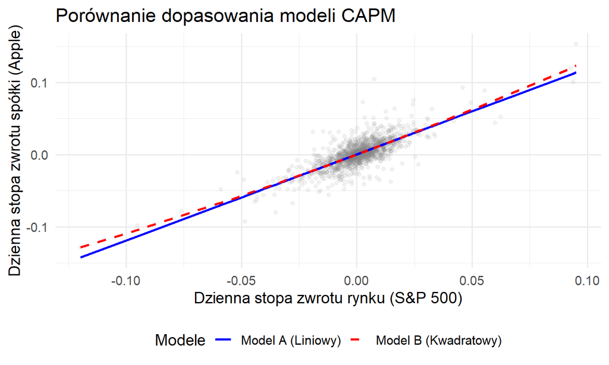

Nałożenie obu linii regresji na chmurę punktów pozwala wizualnie ocenić różnicę.

**Wniosek:** Czerwona, przerywana linia (Model B) wykazuje lekką **wypukłość (∪)**, lepiej dopasowując się do danych w skrajnych punktach (podczas krachów i euforii). Różnica z pewnością nie jest tu wielka, co zgadza się z obliczonymi wartościami AIC.

## Wyniki: Interpretacja Parametrów (Model B)

Skupiamy się na wybranym przez AIC Modelu B. Sprawdzamy statystyczną istotność obliczonych parametrów, korzystając z testu t-Studenta.

Oszacowane parametry dla Modelu B (Kwadratowego)

|  | Estimate | Std. Error | t value | Pr(>\|t\|) |
| --- | --- | --- | --- | --- |
| (Intercept) | 0.00023 | 0.0003 | 0.673 | 0.5011 |
| x | 1.19568 | 0.0245 | 48.811 | 0.0000 |
| x_kwadrat | 1.02733 | 0.4674 | 2.198 | 0.0281 |

**Interpretacja:**

### Wyniki: Hipoteza o normalności Reszt

Sprawdzamy założenie o normalności reszt dla modelu B.

> \(H_0\): Reszty mają rozkład normalny.

```r
#Test Shapiro-Wilka na resztach (limit 5000)
reszty_B <- residuals(model_B)
if(length(reszty_B) > 5000) {
  shapiro.test(sample(reszty_B, 5000))
} else {
  shapiro.test(reszty_B)
}
```

```
##
##  Shapiro-Wilk normality test
##
## data:  reszty_B
## W = 0.95045, p-value < 2.2e-16
```

**Wniosek:** p-value jest ekstremalnie małe (< 0.05), więc **odrzucamy \(H_0\)**. Reszty nie są normalne.

### Wyniki: Normalność Reszt (wizualnie)

Wykres Q-Q potwierdza brak normalności.

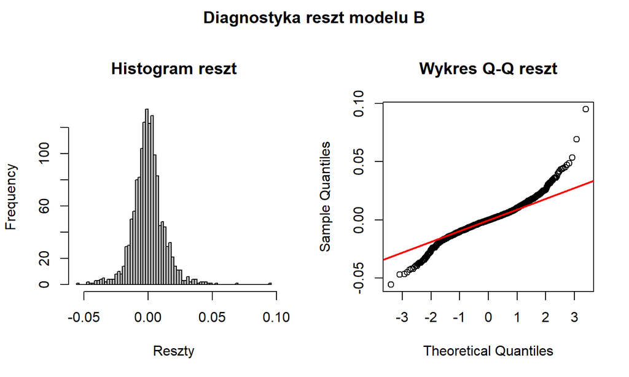

**Interpretacja:** Wykresy (szczególnie Q-Q) pokazują występowanie wartości odstających. Ekstremalne zdarzenia (krachy, euforie) są częstsze niż w rozkładzie normalnym.

## Wnioski Końcowe

1. **Model kwadratowy (Model B) okazał się lepszy** od klasycznego, liniowego modelu CAPM (na podstawie niższego AIC).
2. Znaleźliśmy **istotny statystycznie**, przy \({\alpha}\)=0.05, parametr \(\gamma\) (przy \(x^2\)), co jest dowodem na **nieliniową zależność** między zwrotami z Apple a rynkiem (tzw. market timing).
3. Oznacza to, że klasyczny model CAPM jest **niewystarczający** do pełnego opisu ryzyka spółki Apple w badanym okresie.
4. Diagnostyka reszt wykazała brak normalności (wartości odstające), co potwierdza, że model można by dalej rozwijać (np. o modele GARCH).

## Inne spółki dające ciekawe wyniki:

- **Advanced Micro Devices (AMD)** - model kwadratowy z \({\gamma}\) = 1.6 - spółka agresywna
- **The Boeing Company (BO)** - model kwadratowy z \({\gamma}\) < 0 (wykres wklęsły) - spółka stabilna
- **ETF na złoto (GLD)** - model liniowy (ale wyjaśniający jedynie 1.6% zmienności!)

## Użyte Pakiety 📦

### `quantmod`

- **Autor:** Jeffrey A. Ryan oraz Joshua M. Ulrich.
- **Cel:** Pakiet `quantmod` (Quantitative Financial Modelling) to zestaw narzędzi do pobierania, analizowania i wizualizowania danych finansowych.
- **Wybrane funkcje:**
  - `getSymbols(Ticker, src = "yahoo")`: Służy do pobierania danych historycznych z różnych źródeł (np. Yahoo Finance, FRED). W naszym projekcie pobraliśmy “AAPL” i “^GSPC”.
  - `dailyReturn(x)`: Oblicza stopy zwrotu (domyślnie arytmetyczne).
  - `Ad(x)`: Ekstrahuje kolumnę “Adjusted” (skorygowana cena zamknięcia) z pobranego obiektu `xts`.

### `ggplot2`

- **Autor:** Hadley Wickham.
- **Cel:** Najpopularniejszy pakiet do wizualizacji danych w R. Pozwala na budowanie wykresów.
- **Wybrane funkcje:**
  - `ggplot(data, aes(...))`: Inicjalizuje obiekt wykresu i definiuje parametry.
  - `geom_point()`: Dodaje warstwę punktów (wykres rozrzutu).
  - `geom_line()`: Dodaje warstwę linii.
  - `labs()`: Służy do definiowania wszystkich etykiet (tytuł, podtytuł, osie, legenda).